# Predict Bike Sharing Demand with AutoGluon Template

## Project: Predict Bike Sharing Demand with AutoGluon

This notebook is a template with each step that you need to complete for the project.

Please fill in your code where there are explicit `?` markers in the notebook. You are welcome to add more cells and code as you see fit.

Once you have completed all the code implementations, please export your notebook as a HTML file so the reviews can view your code. Make sure you have all outputs correctly outputted.

`File-> Export Notebook As... -> Export Notebook as HTML`

There is a writeup to complete as well after all code implememtation is done. Please answer all questions and attach the necessary tables and charts. You can complete the writeup in either markdown or PDF.

Completing the code template and writeup template will cover all of the rubric points for this project.

The rubric contains "Stand Out Suggestions" for enhancing the project beyond the minimum requirements. The stand out suggestions are optional. If you decide to pursue the "stand out suggestions", you can include the code in this notebook and also discuss the results in the writeup file.

## Step 1: Create an account with Kaggle

### Create Kaggle Account and download API key

Below is example of steps to get the API username and key. Each student will have their own username and key.

1. Open account settings.

2. Scroll down to API and click Create New API Token.

3. Open up `kaggle.json` and use the username and key.


## Step 2: Download the Kaggle dataset using the kaggle python library

### Open up Sagemaker Studio and use starter template

1. Notebook should be using a `ml.t3.medium` instance (2 vCPU + 4 GiB)
2. Notebook should be using kernal: `Python 3 (MXNet 1.8 Python 3.7 CPU Optimized)`

### Install packages

```python
!pip install -U pip
!pip install -U setuptools wheel
!pip install -U "mxnet<2.0.0" bokeh==2.0.1
!pip install autogluon --no-cache-dir
# Without --no-cache-dir, smaller aws instances may have trouble installing
```

### Setup Kaggle API Key

```python
# create the .kaggle directory and an empty kaggle.json file
!mkdir -p /root/.kaggle
!touch /root/.kaggle/kaggle.json
!chmod 600 /root/.kaggle/kaggle.json
```

```
mkdir: cannot create directory ‘/root’: Permission denied
touch: cannot touch '/root/.kaggle/kaggle.json': Permission denied
chmod: cannot access '/root/.kaggle/kaggle.json': Permission denied
```

```python
# Fill in your user name and key from creating the kaggle account and API token file
import json
kaggle_username = "naifmersal"
kaggle_key = "1bb338e9fe219b1d2807576c5976760a"

# Save API token the kaggle.json file
with open("/root/.kaggle/kaggle.json", "w") as f:
    f.write(json.dumps({"username": kaggle_username, "key": kaggle_key}))
```

[output not shown]

### Download and explore dataset

### Go to the bike sharing demand competition and agree to the terms

```python
# Download the dataset, it will be in a .zip file so you'll need to unzip it as well.
!kaggle competitions download -c bike-sharing-demand
# If you already downloaded it you can use the -o command to overwrite the file
!unzip -o bike-sharing-demand.zip
```

```python
import pandas as pd
from autogluon.tabular import TabularPredictor
```

```python
# Create the train dataset in pandas by reading the csv
# Set the parsing of the datetime column so you can use some of the `dt` features in pandas later
train = pd.read_csv('train.csv', parse_dates=['datetime'])
train.head()
```

|  | datetime | season | holiday | workingday | weather | temp | atemp | humidity | windspeed | casual | registered | count |
| --- | --- | --- | --- | --- | --- | --- | --- | --- | --- | --- | --- | --- |
| 0 | 2011-01-01 00:00:00 | 1 | 0 | 0 | 1 | 9.84 | 14.395 | 81 | 0.0 | 3 | 13 | 16 |
| 1 | 2011-01-01 01:00:00 | 1 | 0 | 0 | 1 | 9.02 | 13.635 | 80 | 0.0 | 8 | 32 | 40 |
| 2 | 2011-01-01 02:00:00 | 1 | 0 | 0 | 1 | 9.02 | 13.635 | 80 | 0.0 | 5 | 27 | 32 |
| 3 | 2011-01-01 03:00:00 | 1 | 0 | 0 | 1 | 9.84 | 14.395 | 75 | 0.0 | 3 | 10 | 13 |
| 4 | 2011-01-01 04:00:00 | 1 | 0 | 0 | 1 | 9.84 | 14.395 | 75 | 0.0 | 0 | 1 | 1 |

```python
# Simple output of the train dataset to view some of the min/max/varition of the dataset features.
train.describe()
```

|  | season | holiday | workingday | weather | temp | atemp | humidity | windspeed | casual | registered | count |
| --- | --- | --- | --- | --- | --- | --- | --- | --- | --- | --- | --- |
| count | 10886.000000 | 10886.000000 | 10886.000000 | 10886.000000 | 10886.00000 | 10886.000000 | 10886.000000 | 10886.000000 | 10886.000000 | 10886.000000 | 10886.000000 |
| mean | 2.506614 | 0.028569 | 0.680875 | 1.418427 | 20.23086 | 23.655084 | 61.886460 | 12.799395 | 36.021955 | 155.552177 | 191.574132 |
| std | 1.116174 | 0.166599 | 0.466159 | 0.633839 | 7.79159 | 8.474601 | 19.245033 | 8.164537 | 49.960477 | 151.039033 | 181.144454 |
| min | 1.000000 | 0.000000 | 0.000000 | 1.000000 | 0.82000 | 0.760000 | 0.000000 | 0.000000 | 0.000000 | 0.000000 | 1.000000 |
| 25% | 2.000000 | 0.000000 | 0.000000 | 1.000000 | 13.94000 | 16.665000 | 47.000000 | 7.001500 | 4.000000 | 36.000000 | 42.000000 |
| 50% | 3.000000 | 0.000000 | 1.000000 | 1.000000 | 20.50000 | 24.240000 | 62.000000 | 12.998000 | 17.000000 | 118.000000 | 145.000000 |
| 75% | 4.000000 | 0.000000 | 1.000000 | 2.000000 | 26.24000 | 31.060000 | 77.000000 | 16.997900 | 49.000000 | 222.000000 | 284.000000 |
| max | 4.000000 | 1.000000 | 1.000000 | 4.000000 | 41.00000 | 45.455000 | 100.000000 | 56.996900 | 367.000000 | 886.000000 | 977.000000 |

```python
train.drop(['registered','casual'], axis=1, inplace=True)
```

```python
# Create the test pandas dataframe in pandas by reading the csv, remember to parse the datetime!
test = pd.read_csv('test.csv',parse_dates=['datetime'])
test.head()
```

|  | datetime | season | holiday | workingday | weather | temp | atemp | humidity | windspeed |
| --- | --- | --- | --- | --- | --- | --- | --- | --- | --- |
| 0 | 2011-01-20 00:00:00 | 1 | 0 | 1 | 1 | 10.66 | 11.365 | 56 | 26.0027 |
| 1 | 2011-01-20 01:00:00 | 1 | 0 | 1 | 1 | 10.66 | 13.635 | 56 | 0.0000 |
| 2 | 2011-01-20 02:00:00 | 1 | 0 | 1 | 1 | 10.66 | 13.635 | 56 | 0.0000 |
| 3 | 2011-01-20 03:00:00 | 1 | 0 | 1 | 1 | 10.66 | 12.880 | 56 | 11.0014 |
| 4 | 2011-01-20 04:00:00 | 1 | 0 | 1 | 1 | 10.66 | 12.880 | 56 | 11.0014 |

```python
# Same thing as train and test dataset
submission = pd.read_csv('sampleSubmission.csv',parse_dates=['datetime'])
submission.head()
```

|  | datetime | count |
| --- | --- | --- |
| 0 | 2011-01-20 00:00:00 | 0 |
| 1 | 2011-01-20 01:00:00 | 0 |
| 2 | 2011-01-20 02:00:00 | 0 |
| 3 | 2011-01-20 03:00:00 | 0 |
| 4 | 2011-01-20 04:00:00 | 0 |

## Step 3: Train a model using AutoGluon’s Tabular Prediction

Requirements:

- We are prediting `count`, so it is the label we are setting.
- Ignore `casual` and `registered` columns as they are also not present in the test dataset.
- Use the `root_mean_squared_error` as the metric to use for evaluation.
- Set a time limit of 10 minutes (600 seconds).
- Use the preset `best_quality` to focus on creating the best model.

```python
predictor = TabularPredictor(label='count', eval_metric='root_mean_squared_error').fit(train_data=train, presets='best_quality', time_limit=600)
```

[output not shown]

[output cut: 299 more lines]

```
	-52.9943	 = Validation score   (-root_mean_squared_error)
	97.7s	 = Training   runtime
	0.27s	 = Validation runtime
Fitting model: LightGBMLarge_BAG_L2 ... Training model for up to 15.1s of the 15.09s of remaining time.
	Fitting 8 child models (S3F1 - S3F8) | Fitting with ParallelLocalFoldFittingStrategy
	-53.3562	 = Validation score   (-root_mean_squared_error)
	8.66s	 = Training   runtime
	0.33s	 = Validation runtime
Completed 3/20 k-fold bagging repeats ...
Fitting model: WeightedEnsemble_L3 ... Training model for up to 360.0s of the 10.93s of remaining time.
	-50.0485	 = Validation score   (-root_mean_squared_error)
	0.17s	 = Training   runtime
	0.0s	 = Validation runtime
AutoGluon training complete, total runtime = 589.25s ... Best model: "WeightedEnsemble_L3"
TabularPredictor saved. To load, use: predictor = TabularPredictor.load("AutogluonModels/ag-20230523_090045/")
```

### Review AutoGluon's training run with ranking of models that did the best.

```python
predictor.fit_summary()
```

```
*** Summary of fit() ***
Estimated performance of each model:
                     model   score_val  pred_time_val    fit_time  pred_time_val_marginal  fit_time_marginal  stack_level  can_infer  fit_order
0      WeightedEnsemble_L3  -50.048540      11.748235  457.391754                0.000279           0.167246            3       True         22
1   NeuralNetFastAI_BAG_L2  -50.837658      10.560310  347.742627                0.301117          28.096092            2       True         18
2    NeuralNetTorch_BAG_L2  -52.994285      10.528825  417.350581                0.269632          97.704046            2       True         20
3     LightGBMLarge_BAG_L2  -53.356190      10.587634  328.305330                0.328441           8.658795            2       True         21
4   RandomForestMSE_BAG_L2  -53.461652      10.554989  322.113379                0.295796           2.466844            2       True         15
5           XGBoost_BAG_L2  -53.788114      10.386389  324.717036                0.127196           5.070501            2       True         19
6          LightGBM_BAG_L2  -53.948699      10.520607  322.950179                0.261414           3.303643            2       True         14
7     ExtraTreesMSE_BAG_L2  -53.952306      10.552969  320.298733                0.293777           0.652198            2       True         17
8          CatBoost_BAG_L2  -54.274535      10.298211  365.353168                0.039018          45.706633            2       True         16
9        LightGBMXT_BAG_L2  -58.613105      12.754552  331.212826                2.495359          11.566291            2       True         13
10   KNeighborsDist_BAG_L1  -84.125061       0.010846    0.015428                0.010846           0.015428            1       True          2
11     WeightedEnsemble_L2  -84.125061       0.011131    0.216357                0.000285           0.200929            2       True         12
12   KNeighborsUnif_BAG_L1 -101.546199       0.010314    0.014529                0.010314           0.014529            1       True          1
13  RandomForestMSE_BAG_L1 -116.548359       0.277887    0.838812                0.277887           0.838812            1       True          5
14    ExtraTreesMSE_BAG_L1 -124.600676       0.246933    0.380323                0.246933           0.380323            1       True          7
15    LightGBMLarge_BAG_L1 -127.788901       0.735860    6.813834                0.735860           6.813834            1       True         11
16         CatBoost_BAG_L1 -128.745377       0.058521  113.357758                0.058521         113.357758            1       True          6
17          XGBoost_BAG_L1 -128.914606       0.463711    5.266546                0.463711           5.266546            1       True          9
18         LightGBM_BAG_L1 -129.078127       0.935830    4.894035                0.935830           4.894035            1       True          4
19       LightGBMXT_BAG_L1 -129.372685       6.899252   19.708846                6.899252          19.708846            1       True          3
20  NeuralNetFastAI_BAG_L1 -134.933352       0.377277   38.160383                0.377277          38.160383            1       True          8
21   NeuralNetTorch_BAG_L1 -136.291498       0.242760  130.196042                0.242760         130.196042            1       True         10
Number of models trained: 22
Types of models trained:
{'StackerEnsembleModel_XGBoost', 'StackerEnsembleModel_CatBoost', 'StackerEnsembleModel_RF', 'WeightedEnsembleModel', 'StackerEnsembleModel_NNFastAiTabular', 'StackerEnsembleModel_KNN', 'StackerEnsembleModel_LGB', 'StackerEnsembleModel_XT', 'StackerEnsembleModel_TabularNeuralNetTorch'}
Bagging used: True  (with 8 folds)
Multi-layer stack-ensembling used: True  (with 3 levels)
Feature Metadata (Processed):
(raw dtype, special dtypes):
('float', [])                : 3 | ['temp', 'atemp', 'windspeed']
('int', [])                  : 3 | ['season', 'weather', 'humidity']
('int', ['bool'])            : 2 | ['holiday', 'workingday']
('int', ['datetime_as_int']) : 5 | ['datetime', 'datetime.year', 'datetime.month', 'datetime.day', 'datetime.dayofweek']
Plot summary of models saved to file: AutogluonModels/ag-20230523_090045/SummaryOfModels.html
*** End of fit() summary ***
```

```
{'model_types': {'KNeighborsUnif_BAG_L1': 'StackerEnsembleModel_KNN',
  'KNeighborsDist_BAG_L1': 'StackerEnsembleModel_KNN',
  'LightGBMXT_BAG_L1': 'StackerEnsembleModel_LGB',
  'LightGBM_BAG_L1': 'StackerEnsembleModel_LGB',
  'RandomForestMSE_BAG_L1': 'StackerEnsembleModel_RF',
  'CatBoost_BAG_L1': 'StackerEnsembleModel_CatBoost',
  'ExtraTreesMSE_BAG_L1': 'StackerEnsembleModel_XT',
  'NeuralNetFastAI_BAG_L1': 'StackerEnsembleModel_NNFastAiTabular',
  'XGBoost_BAG_L1': 'StackerEnsembleModel_XGBoost',
  'NeuralNetTorch_BAG_L1': 'StackerEnsembleModel_TabularNeuralNetTorch',
  'LightGBMLarge_BAG_L1': 'StackerEnsembleModel_LGB',
  'WeightedEnsemble_L2': 'WeightedEnsembleModel',
  'LightGBMXT_BAG_L2': 'StackerEnsembleModel_LGB',
  'LightGBM_BAG_L2': 'StackerEnsembleModel_LGB',
  'RandomForestMSE_BAG_L2': 'StackerEnsembleModel_RF',
  'CatBoost_BAG_L2': 'StackerEnsembleModel_CatBoost',
  'ExtraTreesMSE_BAG_L2': 'StackerEnsembleModel_XT',
  'NeuralNetFastAI_BAG_L2': 'StackerEnsembleModel_NNFastAiTabular',
  'XGBoost_BAG_L2': 'StackerEnsembleModel_XGBoost',
  'NeuralNetTorch_BAG_L2': 'StackerEnsembleModel_TabularNeuralNetTorch',
  'LightGBMLarge_BAG_L2': 'StackerEnsembleModel_LGB',
  'WeightedEnsemble_L3': 'WeightedEnsembleModel'},
 'model_performance': {'KNeighborsUnif_BAG_L1': -101.54619908446061,
  'KNeighborsDist_BAG_L1': -84.12506123181602,
  'LightGBMXT_BAG_L1': -129.37268518019476,
  'LightGBM_BAG_L1': -129.07812698419147,
  'RandomForestMSE_BAG_L1': -116.54835939455667,
  'CatBoost_BAG_L1': -128.74537689325888,
  'ExtraTreesMSE_BAG_L1': -124.60067564699747,
  'NeuralNetFastAI_BAG_L1': -134.93335249095335,
  'XGBoost_BAG_L1': -128.91460604116526,
  'NeuralNetTorch_BAG_L1': -136.29149766229258,
  'LightGBMLarge_BAG_L1': -127.78890125808039,
  'WeightedEnsemble_L2': -84.12506123181602,
  'LightGBMXT_BAG_L2': -58.613104848695336,
  'LightGBM_BAG_L2': -53.948699397280684,
  'RandomForestMSE_BAG_L2': -53.461652066777795,
  'CatBoost_BAG_L2': -54.274535388904944,
  'ExtraTreesMSE_BAG_L2': -53.95230575737243,
  'NeuralNetFastAI_BAG_L2': -50.8376580057358,
```

[output cut: 223 more lines]

```
 7          17
 8          16
 9          13
 10          2
 11         12
 12          1
 13          5
 14          7
 15         11
 16          6
 17          9
 18          4
 19          3
 20          8
 21         10  }
```

### Create predictions from test dataset

```python
predictions = predictor.predict(test)
predictions.head()
```

```
0    27.138367
1    41.627884
2    46.058872
3    48.857635
4    50.955677
Name: count, dtype: float32
```

#### NOTE: Kaggle will reject the submission if we don't set everything to be > 0.

```python
# Describe the `predictions` series to see if there are any negative values
predictions[predictions<0]
```

```
Series([], Name: count, dtype: float32)
```

```python
# How many negative values do we have?
# NO Negative values
```

```python
# Set them to zero
predictions[predictions==0]=0
predictions
```

```
0        27.138367
1        41.627884
2        46.058872
3        48.857635
4        50.955677
           ...
6488    176.465149
6489    176.469910
6490    160.617157
6491    153.982910
6492    148.067093
Name: count, Length: 6493, dtype: float32
```

### Set predictions to submission dataframe, save, and submit

```python
submission["count"] = predictions
submission.to_csv("submission.csv", index=False)
```

```python
!kaggle competitions submit -c bike-sharing-demand -f submission.csv -m "first raw submission"
```

#### View submission via the command line or in the web browser under the competition's page - `My Submissions`

```python
!kaggle competitions submissions -c bike-sharing-demand | tail -n +1 | head -n 6
```

## Step 4: Exploratory Data Analysis and Creating an additional feature

- Any additional feature will do, but a great suggestion would be to separate out the datetime into hour, day, or month parts.

```python
# create a new feature
train['hour'] =train['datetime'].dt.hour
train['day']=train['datetime'].dt.day
train['month'] = train['datetime'].dt.month
test['hour'] =test['datetime'].dt.hour
test['day']=test['datetime'].dt.day
test['month'] = test['datetime'].dt.month
train.pop('datetime')
test.pop('datetime')
```

```
0      2011-01-20 00:00:00
1      2011-01-20 01:00:00
2      2011-01-20 02:00:00
3      2011-01-20 03:00:00
4      2011-01-20 04:00:00
               ...
6488   2012-12-31 19:00:00
6489   2012-12-31 20:00:00
6490   2012-12-31 21:00:00
6491   2012-12-31 22:00:00
6492   2012-12-31 23:00:00
Name: datetime, Length: 6493, dtype: datetime64[ns]
```

```
array([[<Axes: title={'center': 'season'}>,
        <Axes: title={'center': 'holiday'}>,
        <Axes: title={'center': 'workingday'}>],
       [<Axes: title={'center': 'weather'}>,
        <Axes: title={'center': 'temp'}>,
        <Axes: title={'center': 'atemp'}>],
       [<Axes: title={'center': 'humidity'}>,
        <Axes: title={'center': 'windspeed'}>,
        <Axes: title={'center': 'count'}>],
       [<Axes: title={'center': 'hour'}>,
        <Axes: title={'center': 'day'}>,
        <Axes: title={'center': 'month'}>]], dtype=object)
```

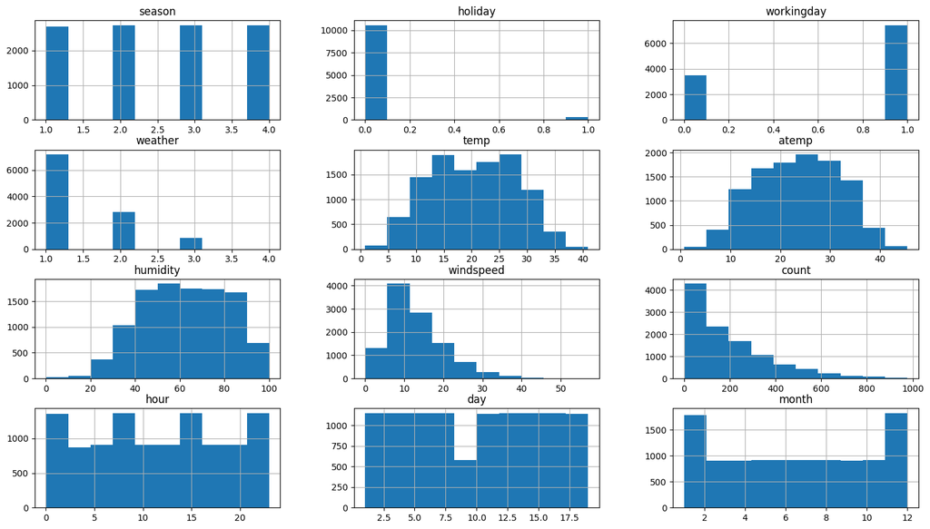

```python
train.hist(figsize=(18,10))
```

```python
sum(train['holiday']==1)/ sum(train['holiday']==0)
```

```
0.029408983451536645
```

```python
train['weather'].value_counts()
```

```
1    7192
2    2834
3     859
4       1
Name: weather, dtype: int64
```

```python
train.corr()
```

|  | season | holiday | workingday | weather | temp | atemp | humidity | windspeed | count | hour | day | month |
| --- | --- | --- | --- | --- | --- | --- | --- | --- | --- | --- | --- | --- |
| season | 1.000000 | 0.029368 | -0.008126 | 0.008879 | 0.258689 | 0.264744 | 0.190610 | -0.147121 | 0.163439 | -0.006546 | 0.001729 | 0.971524 |
| holiday | 0.029368 | 1.000000 | -0.250491 | -0.007074 | 0.000295 | -0.005215 | 0.001929 | 0.008409 | -0.005393 | -0.000354 | -0.015877 | 0.001731 |
| workingday | -0.008126 | -0.250491 | 1.000000 | 0.033772 | 0.029966 | 0.024660 | -0.010880 | 0.013373 | 0.011594 | 0.002780 | 0.009829 | -0.003394 |
| weather | 0.008879 | -0.007074 | 0.033772 | 1.000000 | -0.055035 | -0.055376 | 0.406244 | 0.007261 | -0.128655 | -0.022740 | -0.007890 | 0.012144 |
| temp | 0.258689 | 0.000295 | 0.029966 | -0.055035 | 1.000000 | 0.984948 | -0.064949 | -0.017852 | 0.394454 | 0.145430 | 0.015551 | 0.257589 |
| atemp | 0.264744 | -0.005215 | 0.024660 | -0.055376 | 0.984948 | 1.000000 | -0.043536 | -0.057473 | 0.389784 | 0.140343 | 0.011866 | 0.264173 |
| humidity | 0.190610 | 0.001929 | -0.010880 | 0.406244 | -0.064949 | -0.043536 | 1.000000 | -0.318607 | -0.317371 | -0.278011 | -0.011335 | 0.204537 |
| windspeed | -0.147121 | 0.008409 | 0.013373 | 0.007261 | -0.017852 | -0.057473 | -0.318607 | 1.000000 | 0.101369 | 0.146631 | 0.036157 | -0.150192 |
| count | 0.163439 | -0.005393 | 0.011594 | -0.128655 | 0.394454 | 0.389784 | -0.317371 | 0.101369 | 1.000000 | 0.400601 | 0.019826 | 0.166862 |
| hour | -0.006546 | -0.000354 | 0.002780 | -0.022740 | 0.145430 | 0.140343 | -0.278011 | 0.146631 | 0.400601 | 1.000000 | 0.001132 | -0.006818 |
| day | 0.001729 | -0.015877 | 0.009829 | -0.007890 | 0.015551 | 0.011866 | -0.011335 | 0.036157 | 0.019826 | 0.001132 | 1.000000 | 0.001974 |
| month | 0.971524 | 0.001731 | -0.003394 | 0.012144 | 0.257589 | 0.264173 | 0.204537 | -0.150192 | 0.166862 | -0.006818 | 0.001974 | 1.000000 |

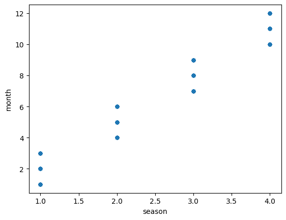

```python
train.plot.scatter(x='season',y='month')
```

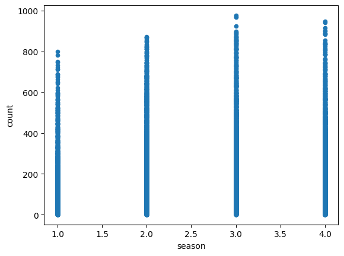

```python
train.plot.scatter(x='season',y='count')
```

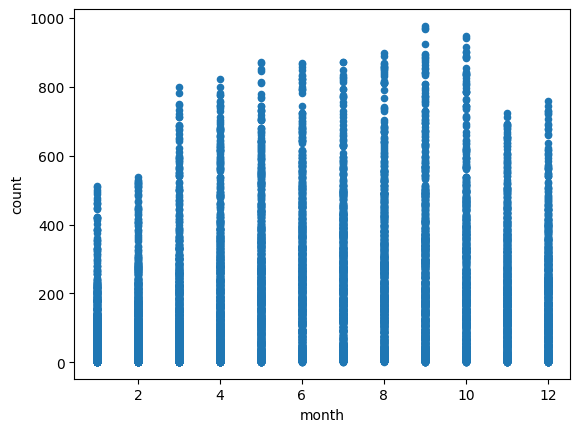

```python
train.plot.scatter(x='month',y='count')
```

```python
train['avg_temp']=(train['temp']+train['atemp'])/2
test['avg_temp']=(test['temp']+test['atemp'])/2
```

```python
train.drop(['temp', 'atemp', 'holiday','month'], axis=1 ,inplace=True)
test.drop(['temp', 'atemp', 'holiday','month'], axis=1 ,inplace=True)
```

```python
train = train.loc[train['weather']!=4,:]
train["weather"].value_counts()
```

```
1    7192
2    2834
3     859
Name: weather, dtype: int64
```

```python
train=train.loc[train['count']<900,:]
```

```python
train.info()
```

```
<class 'pandas.core.frame.DataFrame'>
Int64Index: 10876 entries, 0 to 10885
Data columns (total 9 columns):
 #   Column      Non-Null Count  Dtype
---  ------      --------------  -----
 0   season      10876 non-null  int64
 1   workingday  10876 non-null  int64
 2   weather     10876 non-null  int64
 3   humidity    10876 non-null  int64
 4   windspeed   10876 non-null  float64
 5   count       10876 non-null  int64
 6   hour        10876 non-null  int64
 7   day         10876 non-null  int64
 8   avg_temp    10876 non-null  float64
dtypes: float64(2), int64(7)
memory usage: 849.7 KB
```

## Make category types for these so models know they are not just numbers

- AutoGluon originally sees these as ints, but in reality they are int representations of a category.
- Setting the dtype to category will classify these as categories in AutoGluon.

```python
train["season"] = train['season'].astype('category')
train["weather"] = train['weather'].astype('category')
test["season"] = test['season'].astype('category')
test["weather"] = test['weather'].astype('category')
```

```python
# View are new feature
train.head()
```

|  | season | workingday | weather | humidity | windspeed | count | hour | day | avg_temp |
| --- | --- | --- | --- | --- | --- | --- | --- | --- | --- |
| 0 | 1 | 0 | 1 | 81 | 0.0 | 16 | 0 | 1 | 12.1175 |
| 1 | 1 | 0 | 1 | 80 | 0.0 | 40 | 1 | 1 | 11.3275 |
| 2 | 1 | 0 | 1 | 80 | 0.0 | 32 | 2 | 1 | 11.3275 |
| 3 | 1 | 0 | 1 | 75 | 0.0 | 13 | 3 | 1 | 12.1175 |
| 4 | 1 | 0 | 1 | 75 | 0.0 | 1 | 4 | 1 | 12.1175 |

```
array([[<Axes: title={'center': 'workingday'}>,
        <Axes: title={'center': 'humidity'}>,
        <Axes: title={'center': 'windspeed'}>],
       [<Axes: title={'center': 'count'}>,
        <Axes: title={'center': 'hour'}>,
        <Axes: title={'center': 'day'}>],
       [<Axes: title={'center': 'avg_temp'}>, <Axes: >, <Axes: >]],
      dtype=object)
```

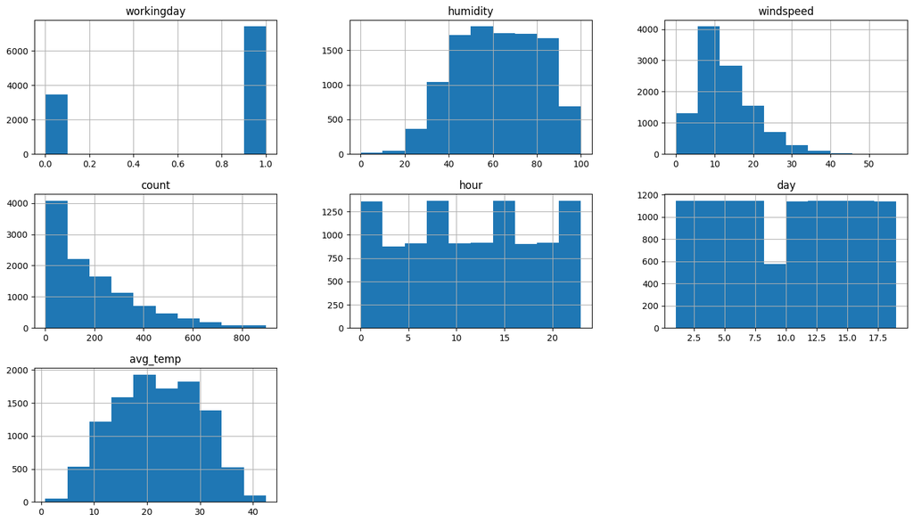

```python
# View histogram of all features again now with the hour feature
train.hist(figsize=(18,10))
```

```python
predictor_new_features = TabularPredictor(label='count', eval_metric='root_mean_squared_error').fit(train_data=train, presets='best_quality', time_limit=600)
```

[output not shown]

[output cut: 372 more lines]

```
	-54.2778	 = Validation score   (-root_mean_squared_error)
	128.62s	 = Training   runtime
	0.77s	 = Validation runtime
Fitting model: LightGBMLarge_BAG_L2 ... Training model for up to 27.86s of the 27.85s of remaining time.
	Fitting 8 child models (S8F1 - S8F8) | Fitting with ParallelLocalFoldFittingStrategy
	-54.3159	 = Validation score   (-root_mean_squared_error)
	16.81s	 = Training   runtime
	0.61s	 = Validation runtime
Completed 8/20 k-fold bagging repeats ...
Fitting model: WeightedEnsemble_L3 ... Training model for up to 360.0s of the 24.62s of remaining time.
	-53.2201	 = Validation score   (-root_mean_squared_error)
	0.17s	 = Training   runtime
	0.0s	 = Validation runtime
AutoGluon training complete, total runtime = 575.56s ... Best model: "WeightedEnsemble_L3"
TabularPredictor saved. To load, use: predictor = TabularPredictor.load("AutogluonModels/ag-20230523_102656/")
```

```python
predictor_new_features.fit_summary()
```

```
*** Summary of fit() ***
Estimated performance of each model:
                     model   score_val  pred_time_val    fit_time  pred_time_val_marginal  fit_time_marginal  stack_level  can_infer  fit_order
0      WeightedEnsemble_L3  -53.220147      28.914766  335.188130                0.000275           0.170538            3       True         22
1   NeuralNetFastAI_BAG_L2  -53.558172      27.716420  259.961019                1.070200          80.767679            2       True         18
2          CatBoost_BAG_L2  -53.826622      26.857207  235.623638                0.210988          56.430298            2       True         16
3          LightGBM_BAG_L2  -53.912190      26.953004  185.219080                0.306785           6.025740            2       True         14
4           XGBoost_BAG_L2  -53.953173      27.014626  189.399720                0.368407          10.206380            2       True         19
5    NeuralNetTorch_BAG_L2  -54.277770      27.415924  307.809825                0.769705         128.616486            2       True         20
6   RandomForestMSE_BAG_L2  -54.311132      26.958112  181.587494                0.311893           2.394155            2       True         15
7     LightGBMLarge_BAG_L2  -54.315924      27.259886  196.003324                0.613667          16.809984            2       True         21
8     ExtraTreesMSE_BAG_L2  -54.345855      26.945985  179.771131                0.299765           0.577791            2       True         17
9      WeightedEnsemble_L2  -54.796487      25.504174   64.817065                0.000270           0.202586            2       True         12
10       LightGBMXT_BAG_L2  -55.015369      27.608204  186.811263                0.961985           7.617923            2       True         13
11       LightGBMXT_BAG_L1  -56.650506      23.006144    6.225366               23.006144           6.225366            1       True          3
12    LightGBMLarge_BAG_L1  -57.234769       1.071680    5.787658                1.071680           5.787658            1       True         11
13         LightGBM_BAG_L1  -57.938892       1.368148    4.112485                1.368148           4.112485            1       True          4
14         CatBoost_BAG_L1  -58.962016       0.063886  100.971277                0.063886         100.971277            1       True          6
15          XGBoost_BAG_L1  -60.220708       0.307609    2.209687                0.307609           2.209687            1       True          9
16   NeuralNetTorch_BAG_L1  -64.482447       0.057932   48.488971                0.057932          48.488971            1       True         10
17    ExtraTreesMSE_BAG_L1  -66.198210       0.273093    0.318756                0.273093           0.318756            1       True          7
18  RandomForestMSE_BAG_L1  -66.408070       0.285272    0.584790                0.285272           0.584790            1       True          5
19  NeuralNetFastAI_BAG_L1  -71.104920       0.135554   10.475564                0.135554          10.475564            1       True          8
20   KNeighborsDist_BAG_L1 -120.818687       0.038625    0.009332                0.038625           0.009332            1       True          2
21   KNeighborsUnif_BAG_L1 -124.048494       0.038277    0.009455                0.038277           0.009455            1       True          1
Number of models trained: 22
Types of models trained:
{'StackerEnsembleModel_XGBoost', 'StackerEnsembleModel_CatBoost', 'StackerEnsembleModel_RF', 'WeightedEnsembleModel', 'StackerEnsembleModel_NNFastAiTabular', 'StackerEnsembleModel_KNN', 'StackerEnsembleModel_LGB', 'StackerEnsembleModel_XT', 'StackerEnsembleModel_TabularNeuralNetTorch'}
Bagging used: True  (with 8 folds)
Multi-layer stack-ensembling used: True  (with 3 levels)
Feature Metadata (Processed):
(raw dtype, special dtypes):
('category', [])  : 2 | ['season', 'weather']
('float', [])     : 2 | ['windspeed', 'avg_temp']
('int', [])       : 3 | ['humidity', 'hour', 'day']
('int', ['bool']) : 1 | ['workingday']
Plot summary of models saved to file: AutogluonModels/ag-20230523_102656/SummaryOfModels.html
*** End of fit() summary ***
```

```
{'model_types': {'KNeighborsUnif_BAG_L1': 'StackerEnsembleModel_KNN',
  'KNeighborsDist_BAG_L1': 'StackerEnsembleModel_KNN',
  'LightGBMXT_BAG_L1': 'StackerEnsembleModel_LGB',
  'LightGBM_BAG_L1': 'StackerEnsembleModel_LGB',
  'RandomForestMSE_BAG_L1': 'StackerEnsembleModel_RF',
  'CatBoost_BAG_L1': 'StackerEnsembleModel_CatBoost',
  'ExtraTreesMSE_BAG_L1': 'StackerEnsembleModel_XT',
  'NeuralNetFastAI_BAG_L1': 'StackerEnsembleModel_NNFastAiTabular',
  'XGBoost_BAG_L1': 'StackerEnsembleModel_XGBoost',
  'NeuralNetTorch_BAG_L1': 'StackerEnsembleModel_TabularNeuralNetTorch',
  'LightGBMLarge_BAG_L1': 'StackerEnsembleModel_LGB',
  'WeightedEnsemble_L2': 'WeightedEnsembleModel',
  'LightGBMXT_BAG_L2': 'StackerEnsembleModel_LGB',
  'LightGBM_BAG_L2': 'StackerEnsembleModel_LGB',
  'RandomForestMSE_BAG_L2': 'StackerEnsembleModel_RF',
  'CatBoost_BAG_L2': 'StackerEnsembleModel_CatBoost',
  'ExtraTreesMSE_BAG_L2': 'StackerEnsembleModel_XT',
  'NeuralNetFastAI_BAG_L2': 'StackerEnsembleModel_NNFastAiTabular',
  'XGBoost_BAG_L2': 'StackerEnsembleModel_XGBoost',
  'NeuralNetTorch_BAG_L2': 'StackerEnsembleModel_TabularNeuralNetTorch',
  'LightGBMLarge_BAG_L2': 'StackerEnsembleModel_LGB',
  'WeightedEnsemble_L3': 'WeightedEnsembleModel'},
 'model_performance': {'KNeighborsUnif_BAG_L1': -124.0484943926169,
  'KNeighborsDist_BAG_L1': -120.81868690131321,
  'LightGBMXT_BAG_L1': -56.65050576885339,
  'LightGBM_BAG_L1': -57.93889233339266,
  'RandomForestMSE_BAG_L1': -66.40806967582847,
  'CatBoost_BAG_L1': -58.962016169073095,
  'ExtraTreesMSE_BAG_L1': -66.19821021243689,
  'NeuralNetFastAI_BAG_L1': -71.10491994028865,
  'XGBoost_BAG_L1': -60.22070757691395,
  'NeuralNetTorch_BAG_L1': -64.48244727125555,
  'LightGBMLarge_BAG_L1': -57.23476888313168,
  'WeightedEnsemble_L2': -54.79648662047186,
  'LightGBMXT_BAG_L2': -55.01536930273211,
  'LightGBM_BAG_L2': -53.91219044354891,
  'RandomForestMSE_BAG_L2': -54.31113221098464,
  'CatBoost_BAG_L2': -53.82662181689556,
  'ExtraTreesMSE_BAG_L2': -54.345855297959524,
  'NeuralNetFastAI_BAG_L2': -53.55817176625178,
```

[output cut: 223 more lines]

```
 7          21
 8          17
 9          12
 10         13
 11          3
 12         11
 13          4
 14          6
 15          9
 16         10
 17          7
 18          5
 19          8
 20          2
 21          1  }
```

```python
# Remember to set all negative values to zero
predictions_new_feature=predictor_new_features.predict(test)
predictions_new_feature[predictions_new_feature<0]=0
```

[output not shown]

[output cut: 89 more lines]

[output not shown]

```python
# Same submitting predictions
submission_new_features= pd.read_csv('sampleSubmission.csv',parse_dates=['datetime'])
submission_new_features["count"] =predictions_new_feature
submission_new_features.to_csv("submission_new_features.csv", index=False)
```

```python
!kaggle competitions submit -c bike-sharing-demand -f submission_new_features.csv -m "new features"
```

```python
!kaggle competitions submissions -c bike-sharing-demand | tail -n +1 | head -n 6
```

## Step 6: Hyper parameter optimization

- There are many options for hyper parameter optimization.
- Options are to change the AutoGluon higher level parameters or the individual model hyperparameters.
- The hyperparameters of the models themselves that are in AutoGluon. Those need the `hyperparameter` and `hyperparameter_tune_kwargs` arguments.

```python
predictor_new_features.feature_importance(data=train)
```

```
Computing feature importance via permutation shuffling for 8 features using 5000 rows with 5 shuffle sets...
	568.29s	= Expected runtime (113.66s per shuffle set)
	472.82s	= Actual runtime (Completed 5 of 5 shuffle sets)
```

|  | importance | stddev | p_value | n | p99_high | p99_low |
| --- | --- | --- | --- | --- | --- | --- |
| hour | 179.825143 | 2.264182 | 3.015320e-09 | 5 | 184.487126 | 175.163160 |
| avg_temp | 78.615270 | 1.957835 | 4.612101e-08 | 5 | 82.646479 | 74.584061 |
| workingday | 78.493994 | 2.583707 | 1.406634e-07 | 5 | 83.813881 | 73.174106 |
| humidity | 43.662808 | 1.901454 | 4.305072e-07 | 5 | 47.577928 | 39.747688 |
| day | 36.220093 | 1.027960 | 7.777182e-08 | 5 | 38.336677 | 34.103508 |
| season | 36.051505 | 0.617026 | 1.029275e-08 | 5 | 37.321970 | 34.781041 |
| windspeed | 20.723209 | 0.949593 | 5.275795e-07 | 5 | 22.678433 | 18.767984 |
| weather | 17.404541 | 0.689446 | 2.948651e-07 | 5 | 18.824119 | 15.984962 |

```python
import autogluon.core as ag

nn_options = {  # specifies non-default hyperparameter values for neural network models
    'num_epochs': 12,  # number of training epochs (controls training time of NN models)
    'learning_rate': ag.space.Real(0.001, 0.1, default=0.01, log=True),  # learning rate used in training (real-valued hyperparameter searched on log-scale)
    'dropout_prob': ag.space.Real(0.0, 0.5, default=0.1),  # dropout probability (real-valued hyperparameter)
}

gbm_options = {  # specifies non-default hyperparameter values for lightGBM gradient boosted trees
    'num_boost_round':ag.space.Int(lower=100, upper=300, default=150),  # number of boosting rounds (controls training time of GBM models)
    'num_leaves': ag.space.Int(lower=10, upper=30, default=20),  # number of leaves in trees (integer hyperparameter)
}
xgb_options = {'n_estimators': ag.space.Int(lower=100, upper=400, default=150), 'learning_rate':ag.space.Real(0.01, 0.1, log=True), 'max_depth':ag.space.Int(lower=2, upper=10, default=4)}
rf_options={'n_estimators':ag.space.Int(lower=100, upper=400, default=150), 'max_depth':ag.space.Int(lower=2, upper=10, default=4)}
hyperparameters = {  # hyperparameters of each model type
                #    'GBM': gbm_options,
                #    'NN_TORCH': nn_options,
                #    'FASTAI':{},
                   'RF': rf_options,
                   'XGB': xgb_options,
                    'XT': rf_options,
                  }  # When these keys are missing from hyperparameters dict, no models of that type are trained



hyperparameter_tune_kwargs = {  # HPO is not performed unless hyperparameter_tune_kwargs is specified
    'num_trials': 2,
    'scheduler' : 'local',
    'searcher': 'auto',
}
```

```python
predictor_new_hpo = TabularPredictor(label='count', eval_metric='root_mean_squared_error').fit(train_data=train, presets='best_quality',auto_stack=True, time_limit=600, hyperparameters=hyperparameters, hyperparameter_tune_kwargs=hyperparameter_tune_kwargs)
```

[output not shown]

```
Fitted model: RandomForest_BAG_L1/T1 ...
	-118.1067	 = Validation score   (-root_mean_squared_error)
	0.2s	 = Training   runtime
	0.0s	 = Validation runtime
Fitted model: RandomForest_BAG_L1/T2 ...
	-85.8082	 = Validation score   (-root_mean_squared_error)
	0.42s	 = Training   runtime
	0.0s	 = Validation runtime
Hyperparameter tuning model: ExtraTrees_BAG_L1 ... Tuning model for up to 119.96s of the 599.32s of remaining time.
```

```
Fitted model: ExtraTrees_BAG_L1/T1 ...
	-120.3348	 = Validation score   (-root_mean_squared_error)
	0.18s	 = Training   runtime
	0.0s	 = Validation runtime
Fitted model: ExtraTrees_BAG_L1/T2 ...
	-90.0609	 = Validation score   (-root_mean_squared_error)
	0.37s	 = Training   runtime
	0.0s	 = Validation runtime
Hyperparameter tuning model: XGBoost_BAG_L1 ... Tuning model for up to 119.96s of the 598.76s of remaining time.
```

[output not shown]

[output cut: 171 more lines]

```
	-120.6634	 = Validation score   (-root_mean_squared_error)
	7.86s	 = Training   runtime
	0.9s	 = Validation runtime
Fitting model: XGBoost_BAG_L1/T2 ... Training model for up to 329.79s of the 529.88s of remaining time.
	Fitting 8 child models (S20F1 - S20F8) | Fitting with ParallelLocalFoldFittingStrategy
	-66.7697	 = Validation score   (-root_mean_squared_error)
	12.68s	 = Training   runtime
	1.73s	 = Validation runtime
Completed 20/20 k-fold bagging repeats ...
Fitting model: WeightedEnsemble_L2 ... Training model for up to 360.0s of the 528.07s of remaining time.
	-66.7697	 = Validation score   (-root_mean_squared_error)
	0.14s	 = Training   runtime
	0.0s	 = Validation runtime
Fitting 3 L2 models ...
Hyperparameter tuning model: RandomForest_BAG_L2 ... Tuning model for up to 158.38s of the 527.93s of remaining time.
```

```
Fitted model: RandomForest_BAG_L2/T1 ...
	-66.743	 = Validation score   (-root_mean_squared_error)
	0.32s	 = Training   runtime
	0.0s	 = Validation runtime
Fitted model: RandomForest_BAG_L2/T2 ...
	-65.8597	 = Validation score   (-root_mean_squared_error)
	1.04s	 = Training   runtime
	0.0s	 = Validation runtime
Hyperparameter tuning model: ExtraTrees_BAG_L2 ... Tuning model for up to 158.38s of the 526.54s of remaining time.
```

```
Fitted model: ExtraTrees_BAG_L2/T1 ...
	-69.1064	 = Validation score   (-root_mean_squared_error)
	0.2s	 = Training   runtime
	0.0s	 = Validation runtime
Fitted model: ExtraTrees_BAG_L2/T2 ...
	-66.149	 = Validation score   (-root_mean_squared_error)
	0.39s	 = Training   runtime
	0.0s	 = Validation runtime
Hyperparameter tuning model: XGBoost_BAG_L2 ... Tuning model for up to 158.38s of the 525.93s of remaining time.
```

[output not shown]

[output cut: 171 more lines]

```
	-87.2938	 = Validation score   (-root_mean_squared_error)
	9.02s	 = Training   runtime
	0.95s	 = Validation runtime
Fitting model: XGBoost_BAG_L2/T2 ... Training model for up to 455.03s of the 455.02s of remaining time.
	Fitting 8 child models (S20F1 - S20F8) | Fitting with ParallelLocalFoldFittingStrategy
	-65.0543	 = Validation score   (-root_mean_squared_error)
	13.91s	 = Training   runtime
	1.45s	 = Validation runtime
Completed 20/20 k-fold bagging repeats ...
Fitting model: WeightedEnsemble_L3 ... Training model for up to 360.0s of the 453.09s of remaining time.
	-65.0375	 = Validation score   (-root_mean_squared_error)
	0.13s	 = Training   runtime
	0.0s	 = Validation runtime
AutoGluon training complete, total runtime = 147.05s ... Best model: "WeightedEnsemble_L3"
TabularPredictor saved. To load, use: predictor = TabularPredictor.load("AutogluonModels/ag-20230523_105842/")
```

```python
predictor_new_hpo.fit_summary()
```

```
*** Summary of fit() ***
Estimated performance of each model:
                     model   score_val  pred_time_val   fit_time  pred_time_val_marginal  fit_time_marginal  stack_level  can_infer  fit_order
0      WeightedEnsemble_L3  -65.037549       4.076270  36.143891                0.000276           0.134540            3       True         14
1        XGBoost_BAG_L2/T2  -65.054264       4.075929  35.615251                1.449639          13.908647            2       True         13
2   RandomForest_BAG_L2/T2  -65.859703       2.626338  22.748246                0.000048           1.041643            2       True          9
3     ExtraTrees_BAG_L2/T2  -66.149037       2.626355  22.100704                0.000065           0.394101            2       True         11
4   RandomForest_BAG_L2/T1  -66.743002       2.626331  22.025020                0.000041           0.318416            2       True          8
5        XGBoost_BAG_L1/T2  -66.769668       1.729873  12.678518                1.729873          12.678518            1       True          6
6      WeightedEnsemble_L2  -66.769668       1.730144  12.813637                0.000271           0.135119            2       True          7
7     ExtraTrees_BAG_L2/T1  -69.106381       2.626332  21.902230                0.000042           0.195626            2       True         10
8   RandomForest_BAG_L1/T2  -85.808239       0.000049   0.416075                0.000049           0.416075            1       True          2
9        XGBoost_BAG_L2/T1  -87.293810       3.577384  30.730702                0.951093           9.024099            2       True         12
10    ExtraTrees_BAG_L1/T2  -90.060938       0.000050   0.367683                0.000050           0.367683            1       True          4
11  RandomForest_BAG_L1/T1 -118.106698       0.000058   0.202906                0.000058           0.202906            1       True          1
12    ExtraTrees_BAG_L1/T1 -120.334787       0.000049   0.183268                0.000049           0.183268            1       True          3
13       XGBoost_BAG_L1/T1 -120.663391       0.896212   7.858154                0.896212           7.858154            1       True          5
Number of models trained: 14
Types of models trained:
{'StackerEnsembleModel_XGBoost', 'WeightedEnsembleModel', 'StackerEnsembleModel_XT', 'StackerEnsembleModel_RF'}
Bagging used: True  (with 8 folds)
Multi-layer stack-ensembling used: True  (with 3 levels)
Feature Metadata (Processed):
(raw dtype, special dtypes):
('category', [])  : 2 | ['season', 'weather']
('float', [])     : 2 | ['windspeed', 'avg_temp']
('int', [])       : 3 | ['humidity', 'hour', 'day']
('int', ['bool']) : 1 | ['workingday']
Plot summary of models saved to file: AutogluonModels/ag-20230523_105842/SummaryOfModels.html
*** End of fit() summary ***
```

[output not shown]

[output cut: 129 more lines]

```
     fit_order
 0          14
 1          13
 2           9
 3          11
 4           8
 5           6
 6           7
 7          10
 8           2
 9          12
 10          4
 11          1
 12          3
 13          5  }
```

```python
# Remember to set all negative values to zero
predictions_new_hpo=predictor_new_hpo.predict(test)
```

[output not shown]

[output cut: 905 more lines]

[output not shown]

```python
predictions_new_hpo[predictions_new_hpo<0]=0
```

```python
# Same submitting predictions
submission_new_features= pd.read_csv('sampleSubmission.csv',parse_dates=['datetime'])
submission_new_features["count"] =predictions_new_hpo
submission_new_features.to_csv("submission_new_hpo.csv", index=False)
```

```python
!kaggle competitions submit -c bike-sharing-demand -f submission_new_hpo.csv -m "new features with hyperparameters"
```

```python
!kaggle competitions submissions -c bike-sharing-demand | tail -n +1 | head -n 6
```